# R Notebook

## Tidying the Dataset

```r
#checking column names
colnames(df)
```

```
 [1] "X"                                 "id"
 [3] "Gender"                            "Customer.Type"
 [5] "Age"                               "Type.of.Travel"
 [7] "Class"                             "Flight.Distance"
 [9] "Inflight.wifi.service"             "Departure.Arrival.time.convenient"
[11] "Ease.of.Online.booking"            "Gate.location"
[13] "Food.and.drink"                    "Online.boarding"
[15] "Seat.comfort"                      "Inflight.entertainment"
[17] "On.board.service"                  "Leg.room.service"
[19] "Baggage.handling"                  "Checkin.service"
[21] "Inflight.service"                  "Cleanliness"
[23] "Departure.Delay.in.Minutes"        "Arrival.Delay.in.Minutes"
[25] "satisfaction"
```

```r
#converting column names to lowercase
colnames(df) = tolower(colnames(df))
colnames(df)
```

```
 [1] "x"                                 "id"
 [3] "gender"                            "customer.type"
 [5] "age"                               "type.of.travel"
 [7] "class"                             "flight.distance"
 [9] "inflight.wifi.service"             "departure.arrival.time.convenient"
[11] "ease.of.online.booking"            "gate.location"
[13] "food.and.drink"                    "online.boarding"
[15] "seat.comfort"                      "inflight.entertainment"
[17] "on.board.service"                  "leg.room.service"
[19] "baggage.handling"                  "checkin.service"
[21] "inflight.service"                  "cleanliness"
[23] "departure.delay.in.minutes"        "arrival.delay.in.minutes"
[25] "satisfaction"
```

```r
#dropping unnecessary columns
#dropping column X because it is an index column. Similarly, the id column just consist of unique identifications for each entry so it will be dropped too
df <- subset(df, select=-c(x, id))

#verifying that unnecessary columns were dropped
colnames(df)
```

```
 [1] "gender"                            "customer.type"
 [3] "age"                               "type.of.travel"
 [5] "class"                             "flight.distance"
 [7] "inflight.wifi.service"             "departure.arrival.time.convenient"
 [9] "ease.of.online.booking"            "gate.location"
[11] "food.and.drink"                    "online.boarding"
[13] "seat.comfort"                      "inflight.entertainment"
[15] "on.board.service"                  "leg.room.service"
[17] "baggage.handling"                  "checkin.service"
[19] "inflight.service"                  "cleanliness"
[21] "departure.delay.in.minutes"        "arrival.delay.in.minutes"
[23] "satisfaction"
```

```r
#checking for missing values
colSums(is.na(df))
```

```
                           gender                     customer.type                               age
                                0                                 0                                 0
                   type.of.travel                             class                   flight.distance
                                0                                 0                                 0
            inflight.wifi.service departure.arrival.time.convenient            ease.of.online.booking
                                0                                 0                                 0
                    gate.location                    food.and.drink                   online.boarding
                                0                                 0                                 0
                     seat.comfort            inflight.entertainment                  on.board.service
                                0                                 0                                 0
                 leg.room.service                  baggage.handling                   checkin.service
                                0                                 0                                 0
                 inflight.service                       cleanliness        departure.delay.in.minutes
                                0                                 0                                 0
         arrival.delay.in.minutes                      satisfaction
                               83                                 0
```

There were 83 missing values in the arrival delay in minutes column. Given that the dataset has 25976 rows, the rows with missing values in this column will be dropped.

```r
#dropping missing values
df <- na.omit(df)
```

```r
#verifying that the nulls have been dropped
colSums(is.na(subset(df, select=arrival.delay.in.minutes)))
```

```
arrival.delay.in.minutes
                       0
```

```r
#checking the dimensions of the data after dropping nulls
print(dim(df))
```

```
[1] 25893    23
```

```r
#checking for duplicates
nrow(df[duplicated(df),])
```

```
[1] 0
```

There were no duplicates

```r
colnames(df)
```

```
 [1] "gender"                            "customer.type"
 [3] "age"                               "type.of.travel"
 [5] "class"                             "flight.distance"
 [7] "inflight.wifi.service"             "departure.arrival.time.convenient"
 [9] "ease.of.online.booking"            "gate.location"
[11] "food.and.drink"                    "online.boarding"
[13] "seat.comfort"                      "inflight.entertainment"
[15] "on.board.service"                  "leg.room.service"
[17] "baggage.handling"                  "checkin.service"
[19] "inflight.service"                  "cleanliness"
[21] "departure.delay.in.minutes"        "arrival.delay.in.minutes"
[23] "satisfaction"
```

```r
#separating columns representing continuous vs categorical(nominal or ordinal) information

contin = c( "departure.delay.in.minutes","arrival.delay.in.minutes", "flight.distance", "age")
cat = c("satisfaction", "inflight.service","cleanliness","baggage.handling","checkin.service",
        "on.board.service","leg.room.service","seat.comfort","inflight.entertainment",
        "food.and.drink","online.boarding", "ease.of.online.booking","gate.location", "inflight.wifi.service", "departure.arrival.time.convenient", "class", "type.of.travel", "gender","customer.type")
```

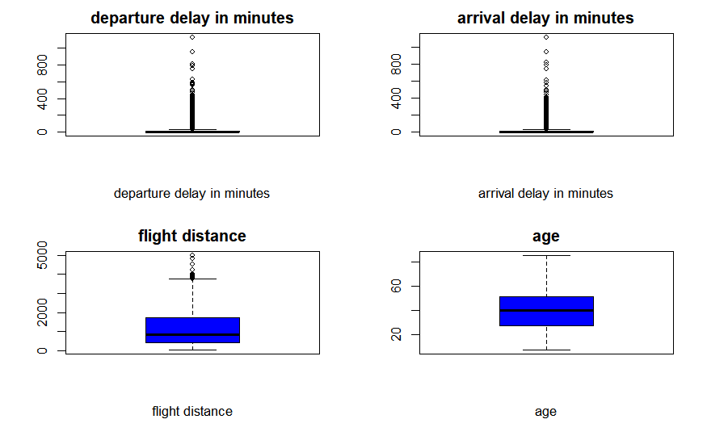

```r
#checking for outliers in continuous columns

#function to replace period in column names with blankspace
repl <- function(x){
gsub(".", " ", x,fixed=TRUE)
}
#checking for outliers in continuous columns
par(mfrow=c(2,2))
for (x in contin){
boxplot(df[x], main=repl(x), xlab=repl(x), col="blue")
}
```

There were outliers in the departure delay in minutes,arrival delay in minutes, and flight distance columns. They will not be dropped because it is possible for the outlier delays and distances recorded to occur.

```r
#checking for anomalies in continuous

#nrow should be zero because none of these variables should be negative
for (x in contin){
  print(paste(x, nrow(subset(df, df[x] < 0))))
}
```

```
[1] "departure.delay.in.minutes 0"
[1] "arrival.delay.in.minutes 0"
[1] "flight.distance 0"
[1] "age 0"
```

```r
#none of the variablesbelow had negative values
```

```r
#checking for number of unique values in categorical(nominal and ordinal) columns
for (x in cat){
  print(paste(x, length(unique(df[[x]]))))
}
```

```
[1] "satisfaction 2"
[1] "inflight.service 6"
[1] "cleanliness 6"
[1] "baggage.handling 5"
[1] "checkin.service 5"
[1] "on.board.service 6"
[1] "leg.room.service 6"
[1] "seat.comfort 5"
[1] "inflight.entertainment 6"
[1] "food.and.drink 6"
[1] "online.boarding 6"
[1] "ease.of.online.booking 6"
[1] "gate.location 5"
[1] "inflight.wifi.service 6"
[1] "departure.arrival.time.convenient 6"
[1] "class 3"
[1] "type.of.travel 2"
[1] "gender 2"
[1] "customer.type 2"
```

```r
#checking for anomalies in categorical

for (x in cat){
  print(x)
  print(unique(df[[x]]))

  print("***************************************")
}
```

```
[1] "satisfaction"
[1] "satisfied"               "neutral or dissatisfied"
[1] "***************************************"
[1] "inflight.service"
[1] 5 4 2 1 3 0
[1] "***************************************"
[1] "cleanliness"
[1] 5 2 4 3 1 0
[1] "***************************************"
[1] "baggage.handling"
[1] 5 4 3 1 2
[1] "***************************************"
[1] "checkin.service"
[1] 2 3 4 1 5
[1] "***************************************"
```

[output cut: 42 more lines]

No anomalous values observed

## Univariate Analysis

```r
par(mfrow=c(2,2))
gender <- table(df$gender)
gender
```

```
Female   Male
 13127  12766
```

```r
barplot(gender, main = 'gender', xlab = 'gender', ylab = 'count', col = 'green')

customer_type <- table(df$customer.type)
customer_type
```

```
disloyal Customer    Loyal Customer
             4782             21111
```

```r
barplot(customer_type, main = 'customer type', xlab = 'customer type', ylab = 'count', col = 'green')
```

```r
type_of_travel <- table(df$type.of.travel)
type_of_travel
```

```
Business travel Personal Travel
          17980            7913
```

```r
barplot(type_of_travel, main = 'travel type', xlab = 'travel type', ylab = 'count', col = 'green')

class <- table(df$class)
class
```

```
Business      Eco Eco Plus
   12457    11524     1912
```

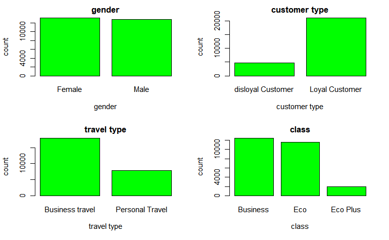

```r
barplot(class, main = 'class', xlab = 'class', ylab = 'count', col = 'green')
```

Most travels were for business purposes

Business class most frequent, closely followed by economy

Slightly more female than male passengers

Most passengers were loyal customer type

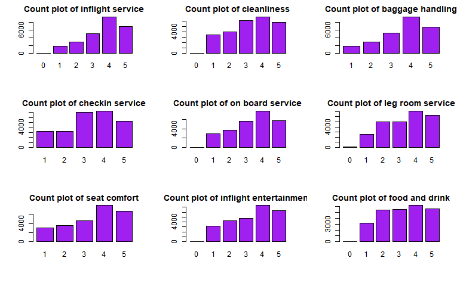

```r
#countplots

par(mfrow=c(3,3))

for (x in cat[2:10]){
barplot(table(df[[x]]), col="purple", main=str_glue("Count plot of {repl(x)}",
 xlab =repl(x), ylab="count"))
}
```

For each of the features above (inflight service, cleanliness, baggage handling, checkin service, on board service, leg room service, seat comfort, and in flight entertainment), the most frequent rating was 4

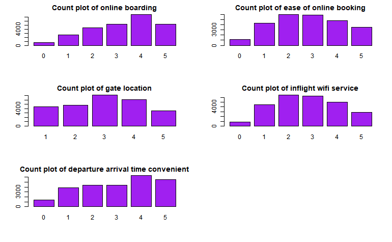

```r
par(mfrow=c(3,2))

for (x in cat[11:15]){
barplot(table(df[[x]]), col="purple", main=str_glue("Count plot of {repl(x)}",
 xlab =repl(x), ylab="count"))
}
```

Most frequent rating for: - online boarding - 4 - ease of online booking - 2 - gate location - 3 - in flight wifi service - 2 - covenience of arrival and departure time - 4

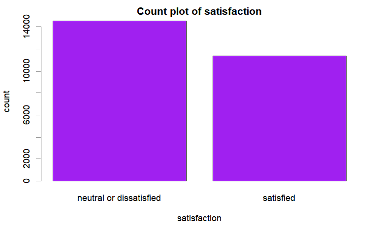

```r
#target column
barplot(table(df$satisfaction), col="purple", main=str_glue("Count plot of satisfaction"),
 xlab ="satisfaction", ylab="count")
```

There were more neutral/dissatisfied customers than satisfied passengers.

```r
par(mfrow = c(2,2))
hist(df$flight.distance, main = 'flight distance', xlab = 'flight distance', col = 'green')
hist(df$departure.delay.in.minutes, main = 'departure delay', xlab = 'departure delay(minutes)', col = 'green')
```

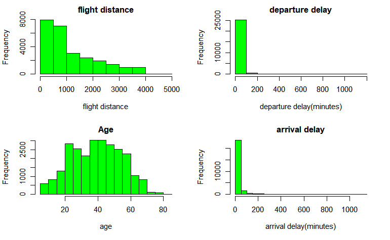

```r
hist(df$age, main ='Age', col = 'green', xlab = 'age')
hist(df$arrival.delay.in.minutes, main = 'arrival delay', xlab = 'arrival delay(minutes)', col = 'green')
```

Most delays were less than 100 minutes

Most flight distances fell in the 0 to 500 bin.

Most passengers were between 20 and 60 years old

```r
#statistical summaries of these continuous variables:
for (x in contin){
  print(describe(df[x]))

}
```

|  | vars | n | mean | sd | median | trimmed | mad | min | max | range | skew | kurtosis | se |
| --- | --- | --- | --- | --- | --- | --- | --- | --- | --- | --- | --- | --- | --- |
| departure.delay.in.minutes | 1 | 25893 | 14.23 | 37.19 | 0 | 5.66 | 0 | 0 | 1128 | 1128 | 7.21 | 103.53 | 0.23 |

|  | vars | n | mean | sd | median | trimmed | mad | min | max | range | skew | kurtosis | se |
| --- | --- | --- | --- | --- | --- | --- | --- | --- | --- | --- | --- | --- | --- |
| arrival.delay.in.minutes | 1 | 25893 | 14.74 | 37.52 | 0 | 6.11 | 0 | 0 | 1115 | 1115 | 6.98 | 97.43 | 0.23 |

|  | vars | n | mean | sd | median | trimmed | mad | min | max | range | skew | kurtosis | se |
| --- | --- | --- | --- | --- | --- | --- | --- | --- | --- | --- | --- | --- | --- |
| flight.distance | 1 | 25893 | 1193.75 | 998.63 | 849 | 1048.69 | 772.43 | 31 | 4983 | 4952 | 1.1 | 0.25 | 6.21 |

|  | vars | n | mean | sd | median | trimmed | mad | min | max | range | skew | kurtosis | se |
| --- | --- | --- | --- | --- | --- | --- | --- | --- | --- | --- | --- | --- | --- |
| age | 1 | 25893 | 39.62 | 15.13 | 40 | 39.64 | 17.79 | 7 | 85 | 78 | 0 | -0.72 | 0.09 |

## Bivariate Analysis

Target column is “satisfaction” - the overall satisfaction with the airline, either satisfied or neutral/dissatisfied

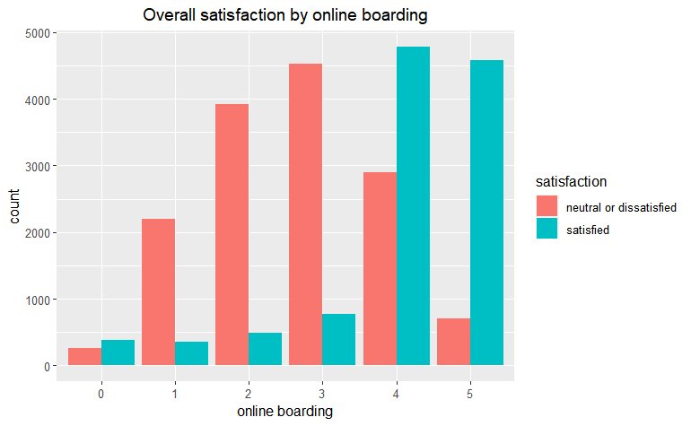

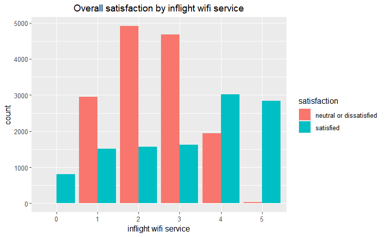

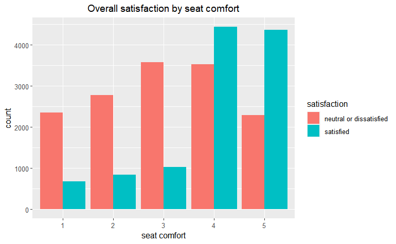

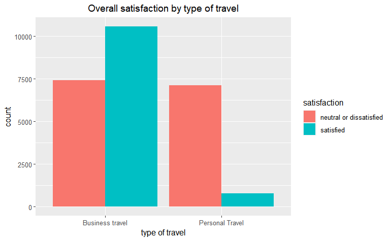

```r
cols <- c("online.boarding", "inflight.wifi.service", "seat.comfort", "type.of.travel")

#satisfaction
for (col in cols){
print(ggplot() + geom_bar(
 data=df,
 aes(x=factor(df[[col]]), fill = factor(satisfaction)
 ), position="dodge") + labs(title = str_glue("Overall satisfaction by {repl(col)}"),
 y="count", x=repl(col), fill="satisfaction") + theme(plot.title =
element_text(hjust=0.5)))
}
```

The proportion of those whose overall satisfaction level was “satisfied” was higher than that of neutral/dissatisfied among those who gave online boarding, inflight wifi service, and seat comfort ratings of 4 or 5.

Most people travelling for business purposes were overall satisfied with the airline while most personal travellers were dissatisfied or neutral.

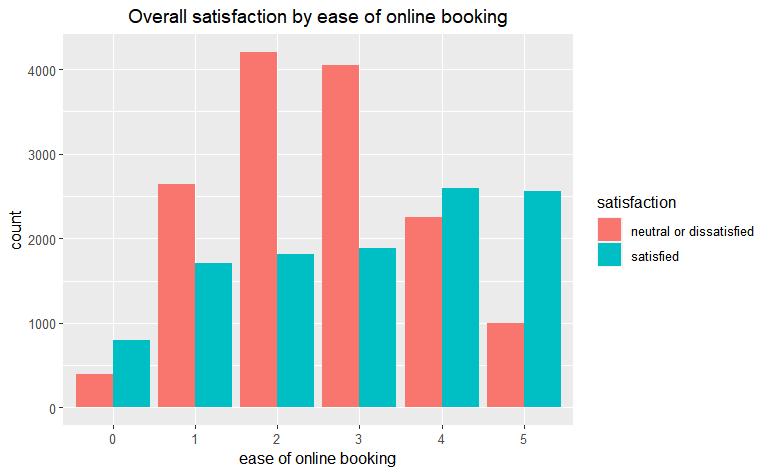

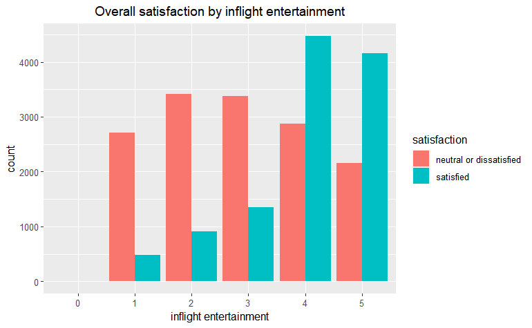

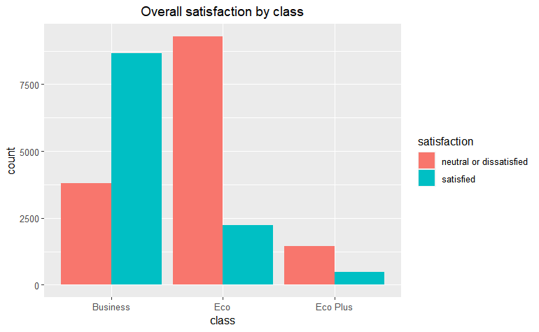

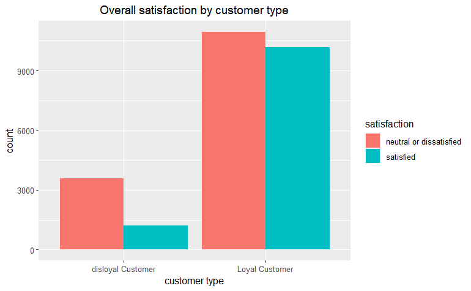

```r
cols <- c("ease.of.online.booking", "inflight.entertainment", "class", "customer.type")

#satisfaction
for (col in cols){
print(ggplot() + geom_bar(
 data=df,
 aes(x=factor(df[[col]]), fill = factor(satisfaction)
 ), position="dodge") + labs(title = str_glue("Overall satisfaction by {repl(col)}"),
 y="count", x=repl(col), fill="satisfaction") + theme(plot.title =
element_text(hjust=0.5)))
}
```

Observations:

The proportion of those whose overall satisfaction level was “satisfied” was higher than that of neutral/dissatisfied among those who gave inflight entertainment and ease of online booking ratings of 4 or 5.

Most in business class were satisfied with the airline.

The proportion of loyal customers satisfied is greater than the proportion of disloyal who are satisfied.

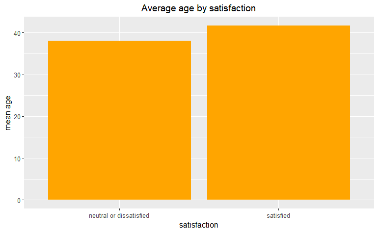

```r
#plotting age and flight distance
par(mfrow=c(1,2))
m = df %>% dplyr::group_by(satisfaction) %>%
dplyr::summarise(mean=mean(age))
ggplot() + geom_col(
data=m,
aes(x=as.factor(satisfaction), y=mean),
fill="orange") + labs(title = "Average age by satisfaction",
y="mean age", x="satisfaction") + theme(plot.title = element_text(hjust=0.5))
```

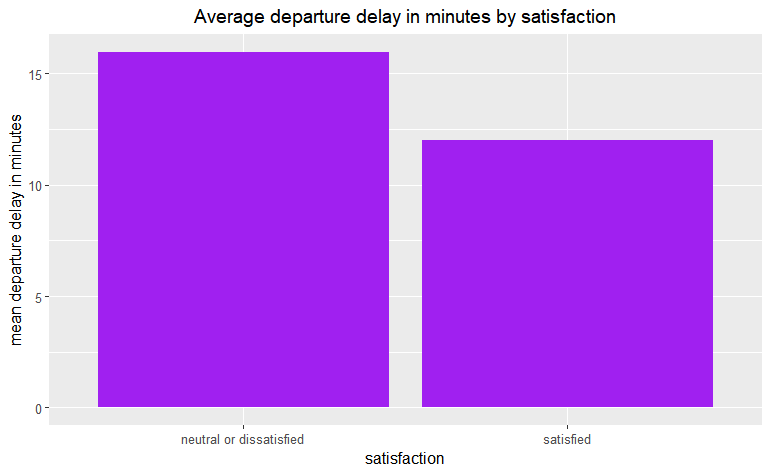

```r
m = df %>% dplyr::group_by(satisfaction) %>%
dplyr::summarise(mean=mean(departure.delay.in.minutes))
ggplot() + geom_col(
data=m,
aes(x=as.factor(satisfaction), y=mean),
fill="purple") + labs(title = "Average departure delay in minutes by satisfaction",
y="mean departure delay in minutes", x="satisfaction") + theme(plot.title = element_text(hjust=0.5))
```

Mean age among those satisfied was higher.

The mean departure delay in minutes experienced was higher among neutral/dissatisfied customers than satisfied customers.

```r
str(df)
```

```
'data.frame':   25893 obs. of  23 variables:
 $ gender                           : chr  "Female" "Female" "Male" "Male" ...
 $ customer.type                    : chr  "Loyal Customer" "Loyal Customer" "disloyal Customer" "Loyal Customer" ...
 $ age                              : int  52 36 20 44 49 16 77 43 47 46 ...
 $ type.of.travel                   : chr  "Business travel" "Business travel" "Business travel" "Business travel" ...
 $ class                            : chr  "Eco" "Business" "Eco" "Business" ...
 $ flight.distance                  : int  160 2863 192 3377 1182 311 3987 2556 556 1744 ...
 $ inflight.wifi.service            : int  5 1 2 0 2 3 5 2 5 2 ...
 $ departure.arrival.time.convenient: int  4 1 0 0 3 3 5 2 2 2 ...
 $ ease.of.online.booking           : int  3 3 2 0 4 3 5 2 2 2 ...
 $ gate.location                    : int  4 1 4 2 3 3 5 2 2 2 ...
 $ food.and.drink                   : int  3 5 2 3 4 5 3 4 5 3 ...
 $ online.boarding                  : int  4 4 2 4 1 5 5 4 5 4 ...
 $ seat.comfort                     : int  3 5 2 4 2 3 5 5 5 4 ...
 $ inflight.entertainment           : int  5 4 2 1 2 5 5 4 5 4 ...
 $ on.board.service                 : int  5 4 4 1 2 4 5 4 2 4 ...
 $ leg.room.service                 : int  5 4 1 1 2 3 5 4 2 4 ...
 $ baggage.handling                 : int  5 4 3 1 2 1 5 4 5 4 ...
 $ checkin.service                  : int  2 3 2 3 4 1 4 5 3 5 ...
 $ inflight.service                 : int  5 4 2 1 2 2 5 4 3 4 ...
 $ cleanliness                      : int  5 5 2 4 4 5 3 3 5 4 ...
 $ departure.delay.in.minutes       : int  50 0 0 0 0 0 0 77 1 28 ...
 $ arrival.delay.in.minutes         : num  44 0 0 6 20 0 0 65 0 14 ...
 $ satisfaction                     : chr  "satisfied" "satisfied" "neutral or dissatisfied" "satisfied" ...
 - attr(*, "na.action")= 'omit' Named int [1:83] 517 657 1072 1225 1590 1817 1833 2772 2912 3195 ...
  ..- attr(*, "names")= chr [1:83] "517" "657" "1072" "1225" ...
```

```r
library(superml)
```

```r
#converting categorical to numerical
vars <- c("gender", "customer.type", "type.of.travel","class", "satisfaction")

#creating a copy of the dataframe
enc_df <- copy(df)

#creating an instance of the label encoder
enc <- LabelEncoder$new()

#encoding

for (var in vars){
  enc_df[[var]] <- enc$fit_transform(factor(enc_df[[var]]))

}



#checking char have been converted to numerical
str(enc_df)
```

```
'data.frame':   25893 obs. of  23 variables:
 $ gender                           : num  0 0 1 1 0 1 0 0 1 0 ...
 $ customer.type                    : num  1 1 0 1 1 1 1 1 1 1 ...
 $ age                              : int  52 36 20 44 49 16 77 43 47 46 ...
 $ type.of.travel                   : num  0 0 0 0 0 0 0 0 0 0 ...
 $ class                            : num  1 0 1 0 1 1 0 0 1 0 ...
 $ flight.distance                  : int  160 2863 192 3377 1182 311 3987 2556 556 1744 ...
 $ inflight.wifi.service            : int  5 1 2 0 2 3 5 2 5 2 ...
 $ departure.arrival.time.convenient: int  4 1 0 0 3 3 5 2 2 2 ...
 $ ease.of.online.booking           : int  3 3 2 0 4 3 5 2 2 2 ...
 $ gate.location                    : int  4 1 4 2 3 3 5 2 2 2 ...
 $ food.and.drink                   : int  3 5 2 3 4 5 3 4 5 3 ...
 $ online.boarding                  : int  4 4 2 4 1 5 5 4 5 4 ...
 $ seat.comfort                     : int  3 5 2 4 2 3 5 5 5 4 ...
 $ inflight.entertainment           : int  5 4 2 1 2 5 5 4 5 4 ...
 $ on.board.service                 : int  5 4 4 1 2 4 5 4 2 4 ...
 $ leg.room.service                 : int  5 4 1 1 2 3 5 4 2 4 ...
 $ baggage.handling                 : int  5 4 3 1 2 1 5 4 5 4 ...
 $ checkin.service                  : int  2 3 2 3 4 1 4 5 3 5 ...
 $ inflight.service                 : int  5 4 2 1 2 2 5 4 3 4 ...
 $ cleanliness                      : int  5 5 2 4 4 5 3 3 5 4 ...
 $ departure.delay.in.minutes       : int  50 0 0 0 0 0 0 77 1 28 ...
 $ arrival.delay.in.minutes         : num  44 0 0 6 20 0 0 65 0 14 ...
 $ satisfaction                     : num  1 1 0 1 1 1 1 1 1 1 ...
 - attr(*, "na.action")= 'omit' Named int [1:83] 517 657 1072 1225 1590 1817 1833 2772 2912 3195 ...
  ..- attr(*, "names")= chr [1:83] "517" "657" "1072" "1225" ...
```

```r
library(reshape2)
```

Plotting heatmap

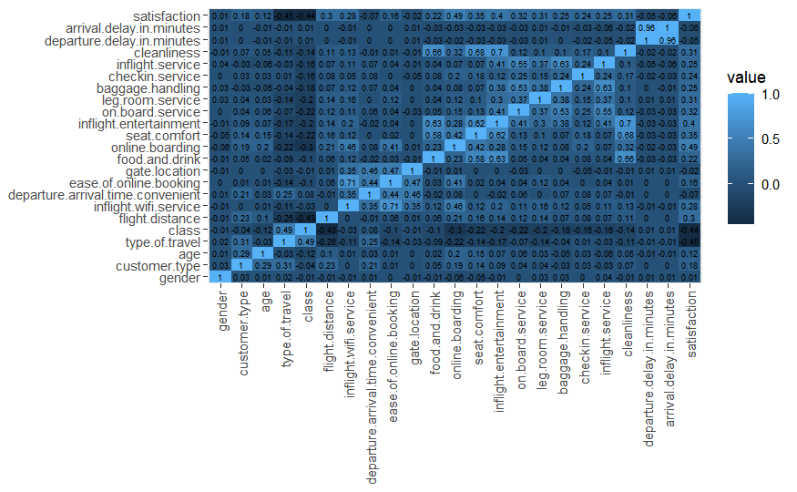

```r
#plotting the correlation heatmap
datam = melt(round(cor(enc_df),2))
ggplot(data=datam, aes(x=Var1, y=Var2, fill=value)) + geom_tile() + geom_text(aes(Var2, Var1, label=value), color="black",size=2) + theme(axis.text.x=element_text(angle=90,vjust=0.5,hjust=1), axis.title.x = element_blank(), axis.title.y = element_blank())
```

According to the matrix, satisfaction appears most correlated to online boarding, type of travel, and class. Modelling will reveal more on the relationships between the predictors and level of passenger satisfaction.

```r
table(df$satisfaction)
```

```
neutral or dissatisfied               satisfied
                  14528                   11365
```

```r
table(enc_df$satisfaction)
```

```
    0     1
14528 11365
```

```r
#the "positive" class is satisfied
```

## Modelling

Splitting to test and train

```r
#stratified 70-30 train test split
set.seed(0)
train <- createDataPartition(enc_df$satisfaction, p=.7, list=FALSE)
# training set
st_train <- enc_df[train,]
# test set
st_test <- enc_df[-train,]

#X and y train and test
X_train <- subset(st_train, select=-satisfaction)
y_train <- subset(st_train, select=satisfaction)
X_test <- subset(st_test, select=-satisfaction)
y_test <- subset(st_test, select=satisfaction)
```

```r
#function calculating accuracy, precision, recall, and f1

pred_metrics <- function(met, t){
  if(met=="precision"){
        p = (t[2,2] / (t[2,2] + t[1,2]))
        p  = round(p, 4)
        paste0('The precision is: ', p)
  }
  else if(met=="f1"){
        p = (t[2,2] / (t[2,2] + t[1,2]))
        s = t[2,2] / (t[2,2] + t[2,1])
        f1 = (2*p*s) / (p + s)
        f1 = round(f1, 4)
        paste0("The F1 score is: ", f1)
  }
  else if(met=="recall"){
        r  = t[2,2] / (t[2,2] + t[2,1])
        r  = round(r,4)
        paste0('The sensitivity(recall) is: ',r)
  }
  else{
        accuracy = (t[2,2] + t[1,1]) / (t[2,2] + t[1,2] + t[1,1] + t[2,1])
        accuracy = round(accuracy, 4)
        paste0("The prediction accuracy is: ", accuracy)
  }
}
```

### Rpart (Decision trees)

```r
library(rpart.plot)
## Loading required package: rpart
library(rpart)
```

```r
library(rattle)
```

```r
#fitting the model

# setting seed for reproducibility
set.seed(100)

#cross validation is done by default
m <- rpart(satisfaction ~ ., data = st_train,
 method = "class")
```

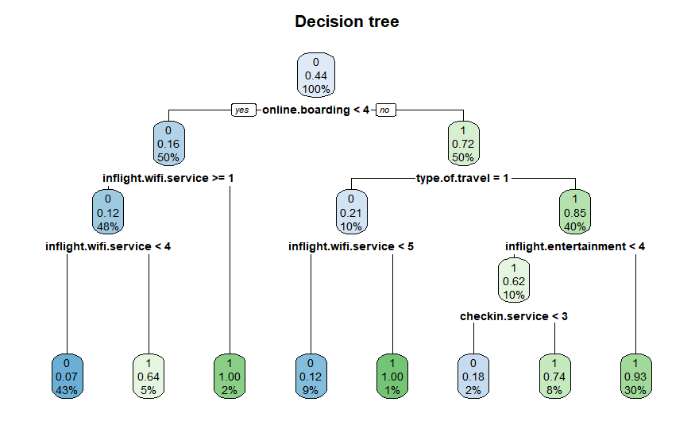

```r
#plotting tree
rpart.plot(m, main="Decision tree")
```

```r
# fancyRpartPlot(m, main="Decision tree", sub="decision tree")
```

```r
#complexity parameter values tried during rpart
m$call
```

```
rpart(formula = satisfaction ~ ., data = st_train, method = "class")
```

```r
m$cptable
```

```
          CP nsplit rel error    xerror        xstd
1 0.50169875      0 1.0000000 1.0000000 0.008406205
2 0.13439034      1 0.4983012 0.4983012 0.007000306
3 0.04240594      2 0.3639109 0.3639109 0.006203716
4 0.03057758      3 0.3215050 0.3215050 0.005895213
5 0.02466339      4 0.2909274 0.2909274 0.005651459
6 0.01554046      5 0.2662640 0.2662640 0.005440005
7 0.01000000      7 0.2351831 0.2395873 0.005194353
```

F1 will be the metric being optimised, as a good balance between precision and recall is being sought on slightly imbalanced data.

```r
f1_list <- list()
```

```r
#predicting and confusion matrix
predictions <- predict(m, X_test, type = "class")
t <- table(y_test$satisfaction,predictions)
t
```

```
   predictions
       0    1
  0 3879  470
  1  344 3074
```

```r
for (val in c("precision", "f1", "recall", "accuracy")){
  print(pred_metrics(val, t))
}
```

```
[1] "The precision is: 0.8674"
[1] "The F1 score is: 0.8831"
[1] "The sensitivity(recall) is: 0.8994"
[1] "The prediction accuracy is: 0.8952"
```

```r
f1_list<-append(f1_list, str_glue('Rpart 1: {pred_metrics("f1", t)}'))
```

```r
#f1_list<-append(f1_list, str_glue('Rpart 1: {pred_metrics("f1", t)}'))
f1_list
```

```
[[1]]
[1] "Rpart 1: The F1 score is: 0.8831"
```

```r
#more detailed evaluation
caret::confusionMatrix(data=as.factor(p), reference=as.factor(y_test[,]),
positive="1")
```

```
Confusion Matrix and Statistics

          Reference
Prediction    0    1
         0 3879  344
         1  470 3074

               Accuracy : 0.8952
                 95% CI : (0.8882, 0.9019)
    No Information Rate : 0.5599
    P-Value [Acc > NIR] : < 2.2e-16

                  Kappa : 0.7882

 Mcnemar's Test P-Value : 1.18e-05

            Sensitivity : 0.8994
            Specificity : 0.8919
         Pos Pred Value : 0.8674
         Neg Pred Value : 0.9185
             Prevalence : 0.4401
         Detection Rate : 0.3958
   Detection Prevalence : 0.4563
      Balanced Accuracy : 0.8956

       'Positive' Class : 1
```

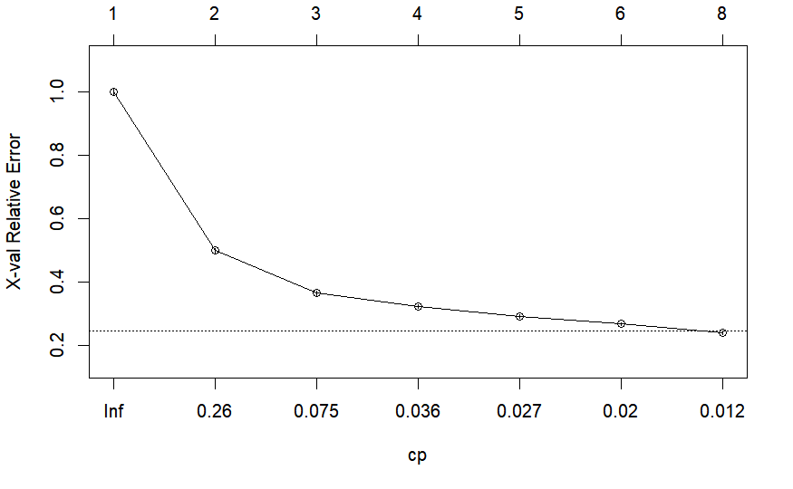

```r
#plotting cp (complexity parameter) values and the size of tree they correspond to,
#against error
plotcp(m)
```

```r
m$cptable
```

```
          CP nsplit rel error    xerror        xstd
1 0.50169875      0 1.0000000 1.0000000 0.008406205
2 0.13439034      1 0.4983012 0.4983012 0.007000306
3 0.04240594      2 0.3639109 0.3639109 0.006203716
4 0.03057758      3 0.3215050 0.3215050 0.005895213
5 0.02466339      4 0.2909274 0.2909274 0.005651459
6 0.01554046      5 0.2662640 0.2662640 0.005440005
7 0.01000000      7 0.2351831 0.2431106 0.005227890
```

Challenging the solution

```r
library(MLmetrics)
```

```r
#target column should be factor when using train function
st_train$satisfaction <- factor(st_train$satisfaction)

#creating custom f1 function to use as metric to optimise
f1 <- function(data, lev = NULL, model = NULL) {
        f1_val <- MLmetrics::F1_Score(y_pred = data$pred,
                                      y_true = data$obs,
                                      positive = lev[1])
        c(F1 = f1_val)
}

set.seed(100)
model <- train(satisfaction ~ .,
 data = st_train,
 method = "rpart",
 tuneLength = 10,
 metric = "F1",
 trControl = trainControl(method = "cv",number = 5,summaryFunction = f1, search = "grid"
 ,verboseIter = FALSE))
# model
## CAR
```

```r
model
```

```
CART

18126 samples
   22 predictor
    2 classes: '0', '1'

No pre-processing
Resampling: Cross-Validated (5 fold)
Summary of sample sizes: 14501, 14502, 14500, 14500, 14501
Resampling results across tuning parameters:

  cp           F1
  0.003271675  0.9274686
  0.003743551  0.9273292
  0.004215427  0.9244770
  0.008179187  0.9129293
  0.015540456  0.8971672
  0.024663395  0.8902277
  0.030577576  0.8803482
  0.042405939  0.8738834
  0.134390336  0.8349257
  0.501698754  0.7618756

F1 was used to select the optimal model using the largest value.
The final value used for the model was cp = 0.003271675.
```

```r
#predicting and confusion matrix
predictions <- predict(model, X_test)
t <- table(y_test$satisfaction,predictions)
t
```

```
   predictions
       0    1
  0 4109  240
  1  340 3078
```

```r
for (val in c("precision", "f1", "recall", "accuracy")){
  print(pred_metrics(val, t))
}
```

```
[1] "The precision is: 0.9277"
[1] "The F1 score is: 0.9139"
[1] "The sensitivity(recall) is: 0.9005"
[1] "The prediction accuracy is: 0.9253"
```

```r
f1_list<-append(f1_list, str_glue('Rpart 2: {pred_metrics("f1", t)}'))
```

```r
#more detailed evaluation
# caret::confusionMatrix(data=as.factor(predictions), reference=as.factor(y_test[,]),
# positive="1")
```

```r
f1_list[1:2]
```

```
[[1]]
[1] "Rpart 1: The F1 score is: 0.8831"

[[2]]
[1] "Rpart 2: The F1 score is: 0.9139"
```

There was an improvement in the f1 to 91.3% for the model formed when using the train function, with the tune length set to 10 and 5 fold cross validation.

### Ranger (Random forests)

```r
set.seed(100)
rfmodel <- train(satisfaction ~ .,
 data = st_train,
 method = "ranger",
 metric = "F1",
 trControl = trainControl(method = "cv",number = 5,summaryFunction = f1, search = "grid"
 ,verboseIter = FALSE))
rfmodel
```

```
Random Forest

18126 samples
   22 predictor
    2 classes: '0', '1'

No pre-processing
Resampling: Cross-Validated (5 fold)
Summary of sample sizes: 14501, 14502, 14500, 14500, 14501
Resampling results across tuning parameters:

  mtry  splitrule   F1
   2    gini        0.9516961
   2    extratrees  0.9472088
  12    gini        0.9600294
  12    extratrees  0.9622289
  22    gini        0.9573937
  22    extratrees  0.9617473

Tuning parameter 'min.node.size' was held constant at a value of 1
F1 was used to select the optimal model using the largest value.
The final values used for the model were mtry = 12, splitrule = extratrees and min.node.size
 = 1.
```

```r
#predicting and confusion matrix
predictions <- predict(rfmodel, X_test)
t <- table(y_test$satisfaction,predictions)
t
```

```
   predictions
       0    1
  0 4230  119
  1  199 3219
```

```r
for (val in c("precision", "f1", "recall", "accuracy")){
  print(pred_metrics(val, t))
}
```

```
[1] "The precision is: 0.9643"
[1] "The F1 score is: 0.9529"
[1] "The sensitivity(recall) is: 0.9418"
[1] "The prediction accuracy is: 0.9591"
```

```r
# f1_list<-append(f1_list, str_glue('Ranger 1: {pred_metrics("f1", t)}'))
```

```r
# f1_list<-append(f1_list, str_glue('Ranger 1: {pred_metrics("f1", t)}'))
f1_list
```

[output not shown]

First ranger model is the best performing across all metrics so far.

Challenging the solution

```r
#tuning min node size as well
grid <- expand.grid(.mtry = c(2,12,22),
 .splitrule = c("gini", "extratrees"),
 .min.node.size = c(1, 5, 10, 15,20)

 )

set.seed(100)


rfmodel2 <- train(satisfaction ~ .,
 data = st_train,
 method = "ranger",
 metric = "F1",
 tuneGrid = grid,
 importance = "impurity",
 trControl = trainControl(method = "cv",number = 5,summaryFunction = f1, search = "grid"
 ,verboseIter = FALSE))
#rfmodel2
```

```r
rfmodel2
```

```
Random Forest

18126 samples
   22 predictor
    2 classes: '0', '1'

No pre-processing
Resampling: Cross-Validated (5 fold)
Summary of sample sizes: 14501, 14502, 14500, 14500, 14501
Resampling results across tuning parameters:

  mtry  splitrule   min.node.size  F1
   2    gini         1             0.9518087
   2    gini         5             0.9510208
   2    gini        10             0.9506274
```

[output cut: 30 more lines]

```r
#predicting and confusion matrix
predictions <- predict(rfmodel2, X_test)
t <- table(y_test$satisfaction,predictions)
t
```

```
   predictions
       0    1
  0 4229  120
  1  194 3224
```

```r
for (val in c("precision", "f1", "recall", "accuracy")){
  print(pred_metrics(val, t))
}
```

```
[1] "The precision is: 0.9641"
[1] "The F1 score is: 0.9536"
[1] "The sensitivity(recall) is: 0.9432"
[1] "The prediction accuracy is: 0.9596"
```

```r
f1_list<-append(f1_list, str_glue('Ranger 2: {pred_metrics("f1", t)}'))
```

```r
#more detailed evaluation
# caret::confusionMatrix(data=as.factor(predictions), reference=as.factor(y_test[,]),
# positive="1")
```

```r
f1_list
```

```
[[1]]
[1] "Rpart 1: The F1 score is: 0.8831"

[[2]]
[1] "Rpart 2: The F1 score is: 0.9139"

[[3]]
[1] "Ranger 1: The F1 score is: 0.9529"

[[4]]
[1] "Ranger 2: The F1 score is: 0.9536"
```

### KNN

```r
#scaling the features

#transforming test based on values obtained from train (scaler should only be
# fitted on train set then used to transform both train and test to prevent
# data leakage caused by fitting on entire dataset)

#obtaining means and standard deviations
m <- colMeans(st_train[1:22])
s <- apply(st_train[1:22], 2, sd)

#creating copies of training and test, scaling the features
st_train_sc <- copy(st_train)
st_test_sc <- copy(st_test)

st_train_sc[1:22] <- scale(st_train[1:22], center = m, scale = s)
st_test_sc[1:22] <- scale(st_test[1:22], center = m, scale = s)
```

```r
library(class)
```

```r
#arbitrary value of 5(odd) as initial k
set.seed(100)
knnpred1 <- knn(train= subset(st_train_sc, select=-satisfaction),test=subset(st_test_sc, select=-satisfaction), cl= st_train_sc$satisfaction, k=5)
```

```r
#predicting and confusion matrix
# predictions <- predict(rfmodel, X_test)
t <- table(y_test$satisfaction,knnpred1)
t
```

```
   knnpred1
       0    1
  0 4164  185
  1  439 2979
```

```r
for (val in c("precision", "f1", "recall", "accuracy")){
  print(pred_metrics(val, t))
}
```

```
[1] "The precision is: 0.9415"
[1] "The F1 score is: 0.9052"
[1] "The sensitivity(recall) is: 0.8716"
[1] "The prediction accuracy is: 0.9197"
```

```r
f1_list<-append(f1_list, str_glue('Knn 1: {pred_metrics("f1", t)}'))
```

```r
f1_list
```

```
[[1]]
[1] "Rpart 1: The F1 score is: 0.8831"

[[2]]
[1] "Rpart 2: The F1 score is: 0.9139"

[[3]]
[1] "Ranger 1: The F1 score is: 0.9529"

[[4]]
[1] "Ranger 2: The F1 score is: 0.9536"

[[5]]
[1] "Knn 1: The F1 score is: 0.9052"
```

The knn is performing well but is not the best model

```r
#k as square root of n
set.seed(100)
kpred1 <- knn(train= subset(st_train_sc, select=-satisfaction),test=subset(st_test_sc, select=-satisfaction), cl= st_train_sc$satisfaction, k=trunc(sqrt(18126)))
```

```r
#k as root n
#predicting and confusion matrix
# predictions <- predict(rfmodel, X_test)
t <- table(y_test$satisfaction,kpred1)
t
```

```
   kpred1
       0    1
  0 4140  209
  1  583 2835
```

```r
for (val in c("precision", "f1", "recall", "accuracy")){
  print(pred_metrics(val, t))
}
```

```
[1] "The precision is: 0.9313"
[1] "The F1 score is: 0.8774"
[1] "The sensitivity(recall) is: 0.8294"
[1] "The prediction accuracy is: 0.898"
```

```r
f1_list<-append(f1_list, str_glue('Knn 2: {pred_metrics("f1", t)}'))
```

```r
f1_list
```

```
[[1]]
[1] "Rpart 1: The F1 score is: 0.8831"

[[2]]
[1] "Rpart 2: The F1 score is: 0.9139"

[[3]]
[1] "Ranger 1: The F1 score is: 0.9529"

[[4]]
[1] "Ranger 2: The F1 score is: 0.9536"

[[5]]
[1] "Knn 1: The F1 score is: 0.9052"

[[6]]
[1] "Knn 2: The F1 score is: 0.8774"
```

Using k as square root of n gives lower metric scores than k as 5

```r
#setting seed for reproducibility
set.seed(100)

knnmod2 <- train(satisfaction ~ ., data = st_train_sc,
 method= "knn", trControl = trainControl(method = "cv",number = 5,summaryFunction = f1, search = "grid"
 ,verboseIter = FALSE),
 tuneLength= 10, metric="F1")
knnmod2
```

```
k-Nearest Neighbors

18126 samples
   22 predictor
    2 classes: '0', '1'

No pre-processing
Resampling: Cross-Validated (5 fold)
Summary of sample sizes: 14501, 14502, 14500, 14500, 14501
Resampling results across tuning parameters:

  k   F1
   5  0.9270045
   7  0.9270573
   9  0.9278780
  11  0.9275187
  13  0.9265784
  15  0.9270376
  17  0.9262665
  19  0.9258176
  21  0.9253060
  23  0.9240599

F1 was used to select the optimal model using the largest value.
The final value used for the model was k = 9.
```

```r
#model above.
#predicting and confusion matrix
predictions <- predict(knnmod2, subset(st_test_sc, select=-satisfaction))
t <- table(y_test$satisfaction,predictions)
t
```

```
   predictions
       0    1
  0 4186  163
  1  453 2965
```

```r
for (val in c("precision", "f1", "recall", "accuracy")){
  print(pred_metrics(val, t))
}
```

```
[1] "The precision is: 0.9479"
[1] "The F1 score is: 0.9059"
[1] "The sensitivity(recall) is: 0.8675"
[1] "The prediction accuracy is: 0.9207"
```

```r
f1_list<-append(f1_list, str_glue('Knn 3: {pred_metrics("f1", t)}'))
f1_list
```

```
[[1]]
[1] "Rpart 1: The F1 score is: 0.8831"

[[2]]
[1] "Rpart 2: The F1 score is: 0.9139"

[[3]]
[1] "Ranger 1: The F1 score is: 0.9529"

[[4]]
[1] "Ranger 2: The F1 score is: 0.9536"

[[5]]
[1] "Knn 1: The F1 score is: 0.9052"

[[6]]
[1] "Knn 2: The F1 score is: 0.8774"

[[7]]
[1] "Knn 3: The F1 score is: 0.9059"
```

The knn model with the train function k=9 is the best knn model with an f1 of 0.9059, but not better than the random forest model 2 with F1 of 0.9536 which is the best so far

### SVM

```r
# Fit the model on scaled features, linear kernel, tuning param
set.seed(100)
svml <- train(satisfaction ~ ., data = st_train_sc,
 method= "svmLinear", trControl = trainControl(method = "cv",number = 5,summaryFunction = f1, search = "grid"
 ,verboseIter = FALSE), metric="F1", tuneGrid = expand.grid(C = seq(0, 2, length = 10)))
#View the model
svml
```

```
Support Vector Machines with Linear Kernel

18126 samples
   22 predictor
    2 classes: '0', '1'

No pre-processing
Resampling: Cross-Validated (5 fold)
Summary of sample sizes: 14501, 14502, 14500, 14500, 14501
Resampling results across tuning parameters:

  C          F1
  0.0000000        NaN
  0.2222222  0.8876992
  0.4444444  0.8877635
  0.6666667  0.8877635
  0.8888889  0.8877736
  1.1111111  0.8878163
  1.3333333  0.8878163
  1.5555556  0.8877635
  1.7777778  0.8878062
  2.0000000  0.8877635

F1 was used to select the optimal model using the largest value.
The final value used for the model was C = 1.111111.
```

```r
#predicting and confusion matrix
predictions <- predict(svml, subset(st_test_sc, select=-satisfaction))
t <- table(y_test$satisfaction,predictions)
t
```

```
   predictions
       0    1
  0 3973  376
  1  566 2852
```

```r
for (val in c("precision", "f1", "recall", "accuracy")){
  print(pred_metrics(val, t))
}
```

```
[1] "The precision is: 0.8835"
[1] "The F1 score is: 0.8583"
[1] "The sensitivity(recall) is: 0.8344"
[1] "The prediction accuracy is: 0.8787"
```

```r
f1_list<-append(f1_list, str_glue('svm linear t: {pred_metrics("f1", t)}'))
```

```r
f1_list
```

```
[[1]]
[1] "Rpart 1: The F1 score is: 0.8831"

[[2]]
[1] "Rpart 2: The F1 score is: 0.9139"

[[3]]
[1] "Ranger 1: The F1 score is: 0.9529"

[[4]]
[1] "Ranger 2: The F1 score is: 0.9536"

[[5]]
[1] "Knn 1: The F1 score is: 0.9052"

[[6]]
[1] "Knn 2: The F1 score is: 0.8774"

[[7]]
[1] "Knn 3: The F1 score is: 0.9059"

[[8]]
[1] "svm linear t: The F1 score is: 0.8583"
```

Linear svm has lowest f1 out of all the models tested so far

```r
# Fit the model on scaled features, polynomial kernel

set.seed(100)

svmp <- train(satisfaction ~ ., data = st_train_sc, method = "svmPoly", trControl = trainControl(method = "cv",number = 3,summaryFunction = f1, search = "grid"
 ,verboseIter = FALSE), metric="F1", tuneLength = 3)
#View the model
svmp
```

```
Support Vector Machines with Polynomial Kernel

18126 samples
   22 predictor
    2 classes: '0', '1'

No pre-processing
Resampling: Cross-Validated (3 fold)
Summary of sample sizes: 12084, 12084, 12084
Resampling results across tuning parameters:

  degree  scale  C     F1
  1       0.001  0.25  0.8837853
  1       0.001  0.50  0.8866367
  1       0.001  1.00  0.8872638
```

[output cut: 27 more lines]

```r
#predicting and confusion matrix
predictions <- predict(svmp, subset(st_test_sc, select=-satisfaction))
t <- table(y_test$satisfaction,predictions)
t
```

```
   predictions
       0    1
  0 4179  170
  1  235 3183
```

```r
for (val in c("precision", "f1", "recall", "accuracy")){
  print(pred_metrics(val, t))
}
```

```
[1] "The precision is: 0.9493"
[1] "The F1 score is: 0.9402"
[1] "The sensitivity(recall) is: 0.9312"
[1] "The prediction accuracy is: 0.9479"
```

```r
f1_list<-append(f1_list, str_glue('svm polynomial t: {pred_metrics("f1", t)}'))
```

```r
f1_list
```

```
[[1]]
[1] "Rpart 1: The F1 score is: 0.8831"

[[2]]
[1] "Rpart 2: The F1 score is: 0.9139"

[[3]]
[1] "Ranger 1: The F1 score is: 0.9529"

[[4]]
[1] "Ranger 2: The F1 score is: 0.9536"

[[5]]
[1] "Knn 1: The F1 score is: 0.9052"

[[6]]
[1] "Knn 2: The F1 score is: 0.8774"

[[7]]
[1] "Knn 3: The F1 score is: 0.9059"

[[8]]
[1] "svm linear t: The F1 score is: 0.8583"

[[9]]
[1] "svm polynomial t: The F1 score is: 0.9402"
```

This svm model with a polynomial kernel has a high F1 score of 0.9402 but this is lower than the benchmark of 0.9536 by the random forest model 2.

```r
# Fit the model on scaled features, radial basis function kernel
set.seed(100)

svmr <- train(satisfaction ~ ., data = st_train_sc, method = "svmRadial", trControl = trainControl(method = "cv",number = 3,summaryFunction = f1, search = "grid"
 ,verboseIter = FALSE), metric="F1", tuneLength = 3)
#View the model
svmr
```

```
Support Vector Machines with Radial Basis Function Kernel

18126 samples
   22 predictor
    2 classes: '0', '1'

No pre-processing
Resampling: Cross-Validated (3 fold)
Summary of sample sizes: 12084, 12084, 12084
Resampling results across tuning parameters:

  C     F1
  0.25  0.9362752
  0.50  0.9426760
  1.00  0.9454447

Tuning parameter 'sigma' was held constant at a value of 0.03000373
F1 was used to select the optimal model using the largest value.
The final values used for the model were sigma = 0.03000373 and C = 1.
```

```r
#predicting and confusion matrix
predictions <- predict(svmr, subset(st_test_sc, select=-satisfaction))
t <- table(y_test$satisfaction,predictions)
t
```

```
   predictions
       0    1
  0 4158  191
  1  242 3176
```

```r
for (val in c("precision", "f1", "recall", "accuracy")){
  print(pred_metrics(val, t))
}
```

```
[1] "The precision is: 0.9433"
[1] "The F1 score is: 0.9362"
[1] "The sensitivity(recall) is: 0.9292"
[1] "The prediction accuracy is: 0.9443"
```

```r
f1_list<-append(f1_list, str_glue('svm radial t: {pred_metrics("f1", t)}'))
```

```r
f1_list
```

```
[[1]]
[1] "Rpart 1: The F1 score is: 0.8831"

[[2]]
[1] "Rpart 2: The F1 score is: 0.9139"

[[3]]
[1] "Ranger 1: The F1 score is: 0.9529"

[[4]]
[1] "Ranger 2: The F1 score is: 0.9536"

[[5]]
[1] "Knn 1: The F1 score is: 0.9052"

[[6]]
[1] "Knn 2: The F1 score is: 0.8774"

[[7]]
[1] "Knn 3: The F1 score is: 0.9059"

[[8]]
[1] "svm linear t: The F1 score is: 0.8583"

[[9]]
[1] "svm polynomial t: The F1 score is: 0.9402"

[[10]]
[1] "svm radial t: The F1 score is: 0.9362"
```

The radial basis function kernel svm model is second best among the support vector models tested, and lower than the benchamrk random forest model.

### Feature importance

The best model was determined to be random forest model 2 (built with ranger), with an f1-score of 0.9536. Other metrics were high as well (precision - 0.9641, recall - 0.9432, accuracy - 0.9596). Feature importances can be extracted from this model

```r
varImp(rfmodel2)
```

```
ranger variable importance

  only 20 most important variables shown (out of 22)
```

|  | Overall |
| --- | --- |
| inflight.wifi.service | 100.0000000 |
| online.boarding | 99.5675601 |
| type.of.travel | 93.0349063 |
| class | 61.6000637 |
| customer.type | 41.9519694 |
| inflight.entertainment | 36.3094433 |
| seat.comfort | 26.4726556 |
| ease.of.online.booking | 19.7691515 |
| baggage.handling | 15.9654758 |
| checkin.service | 15.8981953 |

[output cut: 10 more lines]

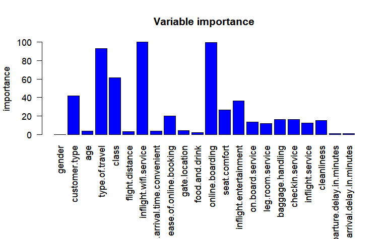

```r
df_vars <- data.frame(m$variable.importance)

par(mar= c(10.1,4.1,4.1,2.1))

barplot(varImp(rfmodel2)$importance$Overall, names=rownames(varImp(rfmodel2)$importance), las=2, col="blue", main="Variable importance"
, ylab="importance")
```

### Modelling summary

The models tested were built applying 4 types of classifiers:

- Decision trees (rpart)
- Random forests (ranger)
- Support vector machines
- K-Nearest-Neighbors

The main metric that was being optimized was the f1-score, because a good balance between precision and recall was being sought, that is, minimising both false positives and negatives. Feature scaling was done before using KNN and SVM. Train-test split of 70-30.

Decision trees:

1. The first model gave an F1 score of 0.8831
2. Tuning the cp (complexity parameter), f1 improved to 0.9139

Random forests:

1. The first model - mtry and splitrule were tuned. F1 of 0.9529 was obtained
2. The two above and min node size additionally were tuned, giving F1 of 0.9536-benchmark

K-nearest neighbour:

1. Initially, an arbitrary odd value (because we have 2 classes) of k as 5 was used. F1 was 0.9052.
2. Using k as the square root of training sample size, f1 was 0.8774
3. Tuning k further resulted in identification of k as 9. That model gave F1 of 0.9059

SVM

1. Linear kernel - Tuning the c parameter. Model gave F1 of 0.8583
2. Polynomial kernel - tuning degree of model (3). Model gave F1-0.9402
3. Rbf kernel - tuning c, sigma constant. F1-0.9362

Best model - random forest with mtry =12, split rule =extra trees, min.node.size =10: F1 0.9536

## Conclusion

Conclusion

The main objectives of the project were achieved:

1. A model that can predict a passenger’s level of satisfaction with high accuracy was built (Best model - a random forest model giving F1 - 0.9536, as well as high values for other metrics (precision : 0.9641, recall: 0.9432,accuracy: 0.9596”))
2. The top factors affecting a passenger’s overall satisfaction level with an airline were identified: (highlighting top 10 respectively) inflight wifi service, online boarding, type of travel, class, customer type, inflight entertainment, seat comfort, ease of online booking, baggage handling, and checkin service.
3. The relationships between overall level of satisfaction and various predictor variables were determined. Some insights:
- The proportion of those whose overall satisfaction level was “satisfied” was higher than that of neutral/dissatisfied among those who gave online boarding, inflight wifi service, seat comfort, inflight entertainment and ease of online booking ratings of 4 or 5.
- Most people travelling for business purposes were overall satisfied with the airline while most personal travellers were dissatisfied or neutral.
- Most in business class were satisfied with the airline as opposed to economy and economy plus where most were dissatified/neutral.

## Recommendations

Recommendations based on some of the top features:

- Airlines should improve the quality and availability of their in flight wifi service to improve overall passenger satisfaction with their airline.
- Customer type. Advertising and encouraging passengers to join loyalty programs and experience perks such as gaining redeemable miles, deals with travel destination accommodation etc, will be beneficial because these programs are likely to increase passenger satisfaction with the airline overall. Customer retention also boosts revenue.
- Online boarding. Checking in online allows passengers to check in in advance, choose their seat, and print their boarding pass. They can therefore avoid the long queues in the airport. A smooth process in doing this improves the passenger experience.
- Airlines should diversify the available selections on their inflight entertainment platforms, such as movies, music, etc to increase the likelihood of a passenger finding something enjoyable.
- Airlines should upgrade the quality of their seats when necessary (for example those that are hard, worn and torn) to maximize on improving comfort for the passengers.
- Ease of online booking was also determined to be an important factor. Airlines should ensure that their online platforms are user-friendly, straightforward and up-to-date when it comes to booking.
- Baggage handling is also a top 10 factor in determining passenger satisfaction. Airlines should ensure that their systems are well-coordinated to avoid cases of delays/loss/damage to baggage.
- The staff at the physical airline check in stations in airports should have good customer service skills, as the impression they make affects overall passenger satisfaction with the airline.